# CITS5014/15 Research Project

### Name: Peter Millitz [23088298] Date: 17/10/2025

# Deep-Learning-Based Techniques for Ship Object Detection and Classification Using Complex-Valued SAR Imagery

## 1. Introduction

This research seeks to investigate the use of high-resolution complex-valued SLC data products from space-based SAR imagery for the tasks of ship detection, classification, and vessel regression using Deep Learning (DL). The basis for this investigation is the hypothesis that fully leveraging the information in the inherently complex-valued SAR imagery should naturally lead to superior model performance compared to real-valued networks. The underlying motivation is to achieve tangible improvements in the performance of existing SAR ship detection models used for maritime surveillance of IUU fishing activity.

## 2. The SARFish dataset

### 2.1 Overview

SARFish is an imagery dataset for the purpose of training, validating and testing supervised machine learning models on the tasks of ship detection, classification and vessel length regression. SARFish builds on the work of the xView3-SAR dataset by expanding the imagery data to include Single Look Complex (SLC) as well as Ground Range Detected (GRD) imagery data taken directly from the European Space Agency (ESA) Copernicus Programme Open Access Hub Website.

The pre-processing applied to the Sentinel-1 images to the SARFish dataset was chosen to be deliberately minimal. The only operations applied to the SARFish data have been those necessary to make the images usable for computer vison tasks and include flipping, debursting and no-data masking. The philosophy was to provide GRD and SLC data in a format as close as practicable to the Sentinel-1 data that can be downloaded from Copernicus.

The three operations applied post download are describe below:

1. **Flipping:** Flipping was applied to both GRD and SLC products. Due to the acquisition methodology, raw images appear as mirror images of the surface of the Earth. This parity inversion between raw images and real-world coordinates is accounted for by reversing the image and its associated ground control points along the range or x-axis.
2. **Debursting:** Debursting was applied only to SLC products. Sentinel-1 SLC products are provided as sets of 3 "swaths" per channel per scene. These swaths consist of "sub-swaths" or "bursts" which are overlapping segments of the image. The process of de-bursting is the alignment of these bursts into a contiguous image. This was done to create a one-to-one correspondence between the objects in each swath and the features on the Earth to which they correspond. It is important to note that as the deburst images are concatenations of bursts which themselves are individual SAR images, there are significant phase discontinuities on the boundaries of the bursts. It was decided for the purposes of this dataset that the bursts within the individual swaths should be merged rather than being split into separate images.
3. **No data masking:** No data masking was applied to both GRD and SLC products. Invalid pixels in the image have been masked using a 'no data' mask.

### 2.2. Dataset download

All SLC (and corresponding GRD) products from the 50 scenes that comprise the 'validation' partition of the SARFish dataset, were downloaded for this project. The SARFish dataset resides in a Hugging Face repository available for download at: https://huggingface.co/datasets/ConnorLuckettDSTG/SARFish. The validation partition was chosen because of the high prevalence of associated labelling where true vessel detections were of `HIGH` and `MEDIUM` confidence and bounding box coordinates were present. In contrast, the 'train' partition, although having many more scenes, lacked labels with 'HIGH' confidence true vessel detections entirely. Moreover, the majority of MEDIUM confidence labels did not have bounding boxes. The exact selection criteria for SLC images based on associated groundtruth labels is shown in Table 1 below.

Table 1. Label criteria required for SLC image selection.

| Attribute | Value(s) |
| --- | --- |
| is_vessel | True |
| is_fishing | True, False |
| confidence | HIGH, MEDIUM |
| top | not missing |
| left | not missing |
| bottom | not missing |
| right | not missing |

A script, kindly supplied by one of the principal authors of the dataset^1, was customised to selectively download 50 SLC scenes selected from the validation partition (see script: *downloader/download_specific_files_from_the_SARFish_dataset_mod.py*). The script requires a specific python environment setup. The *requirements.txt* file used to create the python environment is included in the downloader directory.

- Note: due to the debursting operation, each scene comprises three separate swaths (with small overlap), so the total number of images downloaded is actually 150.

[1] Connor Luckett, connor.luckett@defence.cgov.au

Store a list of qualifying validation partition scenes:

```python
# Create a list of scene ids ('validation' partition) from the 50 selected scenes in the SARFish dataset on Hugging Face
scene_list_val = ["0157baf3866b2cf9v","0d8ed29b0760dc59v","0e309957cef7bdc8v","128443d1e98e2839v","13dd786ee6c95e06v","204e657a411faf4dv","264ed833a13b7f2av","2e80028071b89173v","335f9a411884e9cbv","36076e547370064ev",
                  "377410f6ab9824dfv","3808f5703f0920bfv","39268d50efe8dae9v","3ceef682fbe4930av","3fe00bf7beab8812v","487b4884f467c94av","4a97701b4bd81bf7v","4da9db72dea50504v","590dd08f71056cacv","5c3d986db930f848v",
                  "5e9a2c1bcf179e9bv","65d6f6baee882077v","6a2b6ddecd398c6fv","758991708403f218v","75c03770095c6d9ev","7b7e837a7ac5a880v","8204efcfe9f09f94v","844545c005776fb1v","94dca5e4de2edcf8v","9a5aa7310c195f14v",
                  "9b89b9dcce7dc85ev","9c418af4acd217d1v","9ea5029406691ce4v","a1a21a222e244555v","a6073537a4ea5fb9v","a9a58462f221a9eev","acf76647ba3f524bv","b1844cde847a3942v","c5ea6da5405bfac0v","c8bbfb37522617e9v",
                  "cd36e75010a021f7v","cd4f6ff86f9f5991v","cdc04ca397865356v","e40c9251a4fce150v","eeddcc0db3cff0d8v","f298dbd78ef977d5v","f9eb760aaf6e798dv","fc2f57371370c521v","fc483682c621b54bv","fe6a8d80fb5ebb8ev"]
```

## 3. Setup

```python
from pathlib import Path
import os
from time import time

import numpy as np # np.__version__ = 1.26.4 (had to downgrade to version < 2.0)
import pandas as pd
import matplotlib.pyplot as plt # Added by PJM
import yaml
from GeoTiff import load_GeoTiff
from complex_scale_and_norm import process_complex_data

%gui qt
from visualise_labels import scale_sentinel_1_image, SARFish_Plot
#from SARFish_metric import score

pd.set_option('display.max_colwidth', None)
```

## 4. Exploratory Data Analysis

### 4.1 Statistical summary

```python
!./compute_sar_stats.py
```

```
usage: compute_sar_stats.py [-h] [--pattern {slc-vh,slc-vv,grd-vh,grd-vv}]
                            [--save-array] [-q] [--validate-files]
                            root_path
compute_sar_stats.py: error: the following arguments are required: root_path
```

```python
# Compute statistics for all SLC VH-polarisation .tiff image files in SLC validation partition
#!./compute_sar_stats.py --q --pattern slc-vh --save-array /mnt/h/SARFish/SLC/validation/
```

```python
# Load CSV output file containing SLC image file statistics
df_slc_vh_stats = pd.read_csv('slc-vh_stats.csv')
```

```python
df_slc_vh_stats.head()
```

|  | safe_directory | filename | valid_pixels | nan_count | zero_count | valid_percentage | real_mean | real_std | real_min | real_max | ... | amplitude_min | amplitude_max | amplitude_median | phase_mean | phase_std | phase_min | phase_max | phase_circular_mean | phase_circular_variance | phase_circular_std |
| --- | --- | --- | --- | --- | --- | --- | --- | --- | --- | --- | --- | --- | --- | --- | --- | --- | --- | --- | --- | --- | --- |
| 0 | S1B_IW_SLC__1SDV_20201018T054753_20201018T054820_023863_02D58D_8CE7.SAFE | s1b-iw1-slc-vh-20201018t054754-20201018t054819-023863-02d58d-001_SARFish.tiff | 285029283 | 0 | 36226849 | 100.0 | -0.002757 | 14.997891 | -3529.0 | 2966.0 | ... | 0.0 | 6096.8047 | 13.892444 | 0.078970 | 1.700495 | -3.138905 | 3.141593 | 0.010266 | 0.873502 | 2.033485 |
| 1 | S1B_IW_SLC__1SDV_20201018T054753_20201018T054820_023863_02D58D_8CE7.SAFE | s1b-iw2-slc-vh-20201018t054755-20201018t054820-023863-02d58d-002_SARFish.tiff | 331309224 | 0 | 34412972 | 100.0 | -0.007101 | 23.076190 | -6541.0 | 9334.0 | ... | 0.0 | 9894.8570 | 15.811388 | 0.068502 | 1.721079 | -3.138719 | 3.141593 | -0.013893 | 0.895217 | 2.124083 |
| 2 | S1B_IW_SLC__1SDV_20201018T054753_20201018T054820_023863_02D58D_8CE7.SAFE | s1b-iw3-slc-vh-20201018t054753-20201018t054818-023863-02d58d-003_SARFish.tiff | 318382830 | 0 | 31162632 | 100.0 | 0.002566 | 18.202345 | -4646.0 | 5784.0 | ... | 0.0 | 6370.0454 | 13.341663 | 0.084060 | 1.727526 | -3.138477 | 3.141593 | 0.001231 | 0.901376 | 2.152413 |
| 3 | S1A_IW_SLC__1SDV_20200421T050338_20200421T050406_032221_03BA14_7DD2.SAFE | s1a-iw3-slc-vh-20200421t050338-20200421t050406-032221-03ba14-003_SARFish.tiff | 341956342 | 0 | 20759728 | 100.0 | 0.004107 | 30.860744 | -3417.0 | 5118.0 | ... | 0.0 | 5437.0166 | 24.186773 | 0.066700 | 1.764073 | -3.140158 | 3.141593 | 0.037443 | 0.940950 | 2.378812 |
| 4 | S1A_IW_SLC__1SDV_20200421T050338_20200421T050406_032221_03BA14_7DD2.SAFE | s1a-iw1-slc-vh-20200421t050339-20200421t050404-032221-03ba14-001_SARFish.tiff | 272711592 | 0 | 22474879 | 100.0 | -0.002444 | 23.275122 | -4129.0 | 5132.0 | ... | 0.0 | 5646.9604 | 18.248287 | 0.061543 | 1.741120 | -3.140470 | 3.141593 | -0.018338 | 0.916789 | 2.229967 |

5 rows × 26 columns

`scene_id` needs to be inserted as an additional key in the stats output file (forms part of composite key).

```python
# Add scene column to dataframe
!./add_scene_id.py
```

```
Reading correspondence file...
Creating scene_id mappings...
Processing SLC file: slc-vh_stats.csv
SLC file loaded: 150 rows
SLC file with scene_id saved to: slc-vh_stats_mod.csv
Warning: GRD file not found, skipping...
```

```python
# Load the modified slc-vh stats tabulation into a dataframe
df_slc_vh_stats_mod = pd.read_csv('slc-vh_stats_mod.csv')
```

`scene_id` should now be inserted...

```python
# Display abbreviated list of columns
df_display = (df_slc_vh_stats_mod[['scene_id', 'filename', 'valid_pixels', 'nan_count','zero_count',
                                   'amplitude_mean','amplitude_std','amplitude_min','amplitude_max','amplitude_median',
                                   'phase_circular_mean','phase_min', 'phase_max', 'phase_circular_std']]
              .assign(filename=lambda x: x['filename'].str[:14] + '...'))
df_display
```

|  | scene_id | filename | valid_pixels | nan_count | zero_count | amplitude_mean | amplitude_std | amplitude_min | amplitude_max | amplitude_median | phase_circular_mean | phase_min | phase_max | phase_circular_std |
| --- | --- | --- | --- | --- | --- | --- | --- | --- | --- | --- | --- | --- | --- | --- |
| 0 | 335f9a411884e9cbv | s1b-iw1-slc-vh... | 285029283 | 0 | 36226849 | 15.748271 | 14.217105 | 0.0 | 6096.8047 | 13.892444 | 0.010266 | -3.138905 | 3.141593 | 2.033485 |
| 1 | 335f9a411884e9cbv | s1b-iw2-slc-vh... | 331309224 | 0 | 34412972 | 22.926825 | 23.219760 | 0.0 | 9894.8570 | 15.811388 | -0.013893 | -3.138719 | 3.141593 | 2.124083 |
| 2 | 335f9a411884e9cbv | s1b-iw3-slc-vh... | 318382830 | 0 | 31162632 | 18.143103 | 18.260683 | 0.0 | 6370.0454 | 13.341663 | 0.001231 | -3.138477 | 3.141593 | 2.152413 |
| 3 | 3808f5703f0920bfv | s1a-iw3-slc-vh... | 341956342 | 0 | 20759728 | 32.412090 | 29.226326 | 0.0 | 5437.0166 | 24.186773 | 0.037443 | -3.140158 | 3.141593 | 2.378812 |
| 4 | 3808f5703f0920bfv | s1a-iw1-slc-vh... | 272711592 | 0 | 22474879 | 23.730442 | 22.816694 | 0.0 | 5646.9604 | 18.248287 | -0.018338 | -3.140470 | 3.141593 | 2.229967 |
| ... | ... | ... | ... | ... | ... | ... | ... | ... | ... | ... | ... | ... | ... | ... |
| 145 | 65d6f6baee882077v | s1b-iw2-slc-vh... | 329083515 | 0 | 29897941 | 31.288660 | 27.120457 | 0.0 | 6778.0264 | 25.553865 | -0.009270 | -3.139404 | 3.141593 | 2.189406 |
| 146 | 65d6f6baee882077v | s1b-iw3-slc-vh... | 316267371 | 0 | 26182545 | 32.780293 | 26.831316 | 0.0 | 6383.5500 | 28.301943 | 0.001842 | -3.140020 | 3.141593 | 2.231774 |
| 147 | 65d6f6baee882077v | s1b-iw1-slc-vh... | 284636268 | 0 | 35120348 | 20.447000 | 19.692966 | 0.0 | 8834.3000 | 16.278820 | 0.017757 | -3.139355 | 3.141593 | 2.042816 |
| 148 | 65d6f6baee882077v | s1b-iw2-slc-vh... | 330781988 | 0 | 32423713 | 32.277737 | 25.245028 | 0.0 | 9521.1690 | 28.319605 | 0.003472 | -3.140754 | 3.141593 | 2.155560 |
| 149 | 65d6f6baee882077v | s1b-iw3-slc-vh... | 317898972 | 0 | 31751601 | 12.987852 | 14.863776 | 0.0 | 4694.6284 | 9.000000 | -0.004478 | -3.139029 | 3.141593 | 2.138097 |

150 rows × 14 columns

Print summary statistics for the 150 images:

```python
cols = ['amplitude_mean','amplitude_std','amplitude_min','amplitude_max','amplitude_median','phase_circular_mean','phase_min', 'phase_max', 'phase_circular_std']
column_means = df_display[cols].mean()
print(column_means)
```

```
amplitude_mean           22.942753
amplitude_std            20.336981
amplitude_min             0.000000
amplitude_max          5712.730868
amplitude_median         18.017470
phase_circular_mean       0.035178
phase_min                -3.138837
phase_max                 3.141593
phase_circular_std        2.486439
dtype: float64
```

Examine one image array:

```python
# Load one full-size slc-vh image array (scene_id = '5c3d986db930f848v', swath 2 )
slc_data = np.load('/mnt/h/SARFISH/SLC/validation/arrays/s1b-iw2-slc-vh-20200803t075721-20200803t075746-022756-02b2ff-002_SARFish.npy')
```

```python
print(f"slc_data size:{slc_data.size}, slc_data.shape: {slc_data.shape}, slc_data dtype:{slc_data.dtype}")
```

```
slc_data size:299990055, slc_data.shape: (12237, 24515), slc_data dtype:complex64
```

Plot histograms of the amplitude and phase diistribution:

```python
# Extract the raw amplitude and phase data
vh_mag = np.abs(slc_data)
vh_phase = np.angle(slc_data)
```

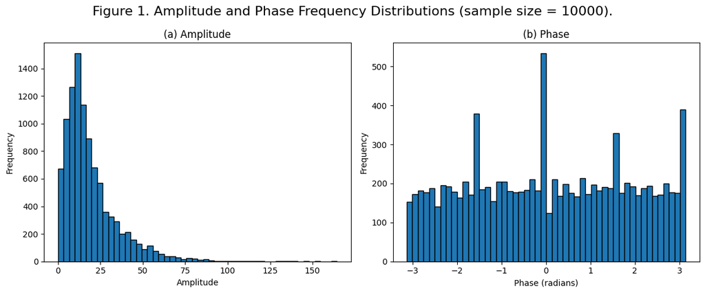

```python
# Plot histograms of raw amplitude and phase (randomly sampled)
sample_size = 10000
vh_mag_sample = np.random.choice(vh_mag.ravel(), sample_size, replace=False)
vh_phase_sample = np.random.choice(vh_phase.ravel(), sample_size, replace=False)

fig, axes = plt.subplots(1, 2, figsize=(12, 5))

# Plot histogram on the first subplot
axes[0].hist(vh_mag_sample, bins=50, edgecolor='black')
axes[0].set_title("(a) Amplitude")
axes[0].set_xlabel("Amplitude")
axes[0].set_ylabel("Frequency")

# Plot histogram on the second subplot
axes[1].hist(vh_phase_sample, bins=50, edgecolor='black')
axes[1].set_title("(b) Phase")
axes[1].set_xlabel("Phase (radians)")
axes[1].set_ylabel("Frequency")

# Add super title
fig.suptitle("Figure 1. Amplitude and Phase Frequency Distributions (sample size = 10000).", fontsize=16)

# Improve layout and show plot
plt.tight_layout()
plt.show()
```

**Observations:**

- Amplitude ranges between 0 and some large value (relative to mean/median) on average. Distribution is long-tailed (Figure 1(a)).
- Phase rangr centred on zero radians with values in the range $(-\pi, \pi]$. Distribution is fairly uniform across the range

  but with consistenlty high frequency peaks around $0$, $\pm\pi/2$ and $\pi$ (Figure 1(b)).
- `phase_max` exceeds $+\pi$ by a very small number ( of the order of $10^-8$), mostly likely due to floating-point precision error.

**Pre-processing recommendations: Scaling and Normalisation**

- *Amplitude:* Logarithmic (decibel) transformation to compress dynamic range:

$\quad\quad\quad\quad\quad\quad\quad\quad\quad\quad\quad\quad\quad\quad\quad\quad\quad\quad vh\_mag\_db = 20\log_{10}(vh\_mag + \epsilon)$,

$\quad$ where $\epsilon$ is some small number (e.g. $10^-6$) to prevent log(0) errors, then normalise to [0, 1] using min/max scaling.

- *Phase:* Focus on maintaining relative structure - normalise only. Since raw value range is $(-\pi, \pi]$, shift phase value by $+\pi$, then divide by $2\pi$ to map to the range [0, 1]:

$\quad\quad\quad\quad\quad\quad\quad\quad\quad\quad\quad\quad\quad\quad\quad\quad\quad\quad phase\_norm = \frac{phase\_shifted}{2\pi}$

### 4.2. Training labels

Examine the SLC 'validation' partition labels

```python
# Load the SLC validation labels into a dataframe
df_labels_val = pd.read_csv('~/CITS5014/SARFish/working/labels/validation/SLC/SLC_validation_labels.csv')
df_labels_val
```

|  | partition | product_type | scene_id | detect_id | SLC_product_identifier | swath_index | detect_lat | detect_lon | detect_scene_column | detect_scene_row | ... | left | bottom | right | vessel_length_m | source | is_vessel | is_fishing | global_shoreline_vector_distance_from_shore_km | xView3_shoreline_distance_from_shore_km | confidence |
| --- | --- | --- | --- | --- | --- | --- | --- | --- | --- | --- | --- | --- | --- | --- | --- | --- | --- | --- | --- | --- | --- |
| 0 | validation | SLC | 5c3d986db930f848v | 5c3d986db930f848v_065.60344616000000428357_-20.89814321000000063577 | S1B_IW_SLC__1SDV_20200803T075720_20200803T075748_022756_02B2FF_E5D2 | 1 | 65.603446 | -20.898143 | 18083.0 | 5388.0 | ... | 18079.0 | 5387.0 | 18087.0 | NaN | manual | True | NaN | 0.130777 | 0.109727 | LOW |
| 1 | validation | SLC | 5c3d986db930f848v | 5c3d986db930f848v_065.60102723999999341231_-20.90357632999999992762 | S1B_IW_SLC__1SDV_20200803T075720_20200803T075748_022756_02B2FF_E5D2 | 1 | 65.601027 | -20.903576 | 18131.0 | 5365.0 | ... | 18124.0 | 5363.0 | 18138.0 | NaN | manual | True | NaN | 0.142263 | 0.071051 | MEDIUM |
| 2 | validation | SLC | 5c3d986db930f848v | 5c3d986db930f848v_065.17134473999999499938_-21.09210240000000169402 | S1B_IW_SLC__1SDV_20200803T075720_20200803T075748_022756_02B2FF_E5D2 | 1 | 65.171345 | -21.092102 | 17649.0 | 1860.0 | ... | 17643.0 | 1859.0 | 17652.0 | NaN | manual | True | NaN | 0.041884 | 0.509684 | MEDIUM |
| 3 | validation | SLC | 5c3d986db930f848v | 5c3d986db930f848v_065.17062706000000105178_-21.09188649000000026490 | S1B_IW_SLC__1SDV_20200803T075720_20200803T075748_022756_02B2FF_E5D2 | 1 | 65.170627 | -21.091886 | 17642.0 | 1855.0 | ... | 17635.0 | 1852.0 | 17649.0 | NaN | manual | True | NaN | 0.044895 | 0.502181 | MEDIUM |
| 4 | validation | SLC | 5c3d986db930f848v | 5c3d986db930f848v_065.70719721999999762829_-20.71366400000000140835 | S1B_IW_SLC__1SDV_20200803T075720_20200803T075748_022756_02B2FF_E5D2 | 1 | 65.707197 | -20.713664 | 16672.0 | 6335.0 | ... | 16655.0 | 6331.0 | 16687.0 | NaN | manual | True | NaN | 0.015443 | 2.789757 | MEDIUM |
| ... | ... | ... | ... | ... | ... | ... | ... | ... | ... | ... | ... | ... | ... | ... | ... | ... | ... | ... | ... | ... | ... |
| 19181 | validation | SLC | 377410f6ab9824dfv | 377410f6ab9824dfv_006.46657020399999993288_003.39077283399999984681 | S1A_IW_SLC__1SDV_20200407T052956_20200407T053026_032017_03B2E2_18FA | 3 | 6.466570 | 3.390773 | 11095.0 | 9420.0 | ... | 11084.0 | 9418.0 | 11105.0 | 41.662661 | manual | True | NaN | 0.012979 | 0.458679 | MEDIUM |
| 19182 | validation | SLC | 377410f6ab9824dfv | 377410f6ab9824dfv_006.46965017399999986480_003.38507763299999986373 | S1A_IW_SLC__1SDV_20200407T052956_20200407T053026_032017_03B2E2_18FA | 3 | 6.469650 | 3.385078 | 11299.0 | 9435.0 | ... | 11285.0 | 9432.0 | 11312.0 | 164.112935 | manual | True | NaN | 0.109386 | 0.194906 | MEDIUM |
| 19183 | validation | SLC | 377410f6ab9824dfv | 377410f6ab9824dfv_006.28999598099999968071_003.23360257100000003661 | S1A_IW_SLC__1SDV_20200407T052956_20200407T053026_032017_03B2E2_18FA | 3 | 6.289996 | 3.233603 | 15029.0 | 7806.0 | ... | 14983.0 | 7799.0 | 15071.0 | 234.084314 | ais/manual | True | False | 9999.990000 | 9999.990000 | HIGH |
| 19184 | validation | SLC | 377410f6ab9824dfv | 377410f6ab9824dfv_006.36177788400000032709_003.31700163200000019970 | S1A_IW_SLC__1SDV_20200407T052956_20200407T053026_032017_03B2E2_18FA | 3 | 6.361778 | 3.317002 | 12791.0 | 8493.0 | ... | 12748.0 | 8488.0 | 12835.0 | 109.963083 | ais/manual | True | False | 4.393870 | 4.767537 | HIGH |
| 19185 | validation | SLC | 377410f6ab9824dfv | 377410f6ab9824dfv_006.36544217700000025673_003.38282932300000016568 | S1A_IW_SLC__1SDV_20200407T052956_20200407T053026_032017_03B2E2_18FA | 3 | 6.365442 | 3.382829 | 10690.0 | 8625.0 | ... | 10680.0 | 8623.0 | 10701.0 | 26.741460 | ais/manual | True | True | 3.317648 | 3.522421 | HIGH |

19186 rows × 21 columns

```python
# Check for duplicates
duplicates_val = df_labels_val[df_labels_val.duplicated(subset=['detect_id'], keep=False)]
duplicates_val.sort_values(by=['detect_lat', 'detect_lon'])
```

|  | partition | product_type | scene_id | detect_id | SLC_product_identifier | swath_index | detect_lat | detect_lon | detect_scene_column | detect_scene_row | ... | left | bottom | right | vessel_length_m | source | is_vessel | is_fishing | global_shoreline_vector_distance_from_shore_km | xView3_shoreline_distance_from_shore_km | confidence |
| --- | --- | --- | --- | --- | --- | --- | --- | --- | --- | --- | --- | --- | --- | --- | --- | --- | --- | --- | --- | --- | --- |
| 18093 | validation | SLC | 128443d1e98e2839v | 128443d1e98e2839v_-01.61587642600000003235_009.03407082600000066464 | S1A_IW_SLC__1SDV_20200907T050725_20200907T050752_034248_03FAD3_1672 | 1 | -1.615876 | 9.034071 | 20249.0 | 4058.0 | ... | 20238.0 | 4052.0 | 20260.0 | 66.770821 | ais/manual | True | False | 9999.990000 | 9999.990000 | HIGH |
| 18215 | validation | SLC | 128443d1e98e2839v | 128443d1e98e2839v_-01.61587642600000003235_009.03407082600000066464 | S1A_IW_SLC__1SDV_20200907T050725_20200907T050752_034248_03FAD3_1672 | 2 | -1.615876 | 9.034071 | 315.0 | 3190.0 | ... | 304.0 | 3185.0 | 326.0 | 66.770821 | ais/manual | True | False | 9999.990000 | 9999.990000 | HIGH |
| 18297 | validation | SLC | 7b7e837a7ac5a880v | 7b7e837a7ac5a880v_003.79945025100000011165_008.10569663200000078973 | S1A_IW_SLC__1SDV_20200831T051418_20200831T051446_034146_03F756_2E58 | 1 | 3.799450 | 8.105697 | 20368.0 | 9090.0 | ... | 20349.0 | 9084.0 | 20386.0 | 82.577575 | ais/manual | True | False | 9999.990000 | 9999.990000 | HIGH |
| 18460 | validation | SLC | 7b7e837a7ac5a880v | 7b7e837a7ac5a880v_003.79945025100000011165_008.10569663200000078973 | S1A_IW_SLC__1SDV_20200831T051418_20200831T051446_034146_03F756_2E58 | 2 | 3.799450 | 8.105697 | 434.0 | 8218.0 | ... | 415.0 | 8212.0 | 452.0 | 82.577575 | ais/manual | True | False | 9999.990000 | 9999.990000 | HIGH |
| 18283 | validation | SLC | 7b7e837a7ac5a880v | 7b7e837a7ac5a880v_003.83147869100000004750_008.11169730099999952699 | S1A_IW_SLC__1SDV_20200831T051418_20200831T051446_034146_03F756_2E58 | 1 | 3.831479 | 8.111697 | 20385.0 | 9347.0 | ... | 20367.0 | 9339.0 | 20402.0 | 73.179787 | ais/manual | True | False | 9999.990000 | 9999.990000 | HIGH |
| ... | ... | ... | ... | ... | ... | ... | ... | ... | ... | ... | ... | ... | ... | ... | ... | ... | ... | ... | ... | ... | ... |
| 145 | validation | SLC | 5c3d986db930f848v | 5c3d986db930f848v_065.60488521000000616823_-21.09645533999999855723 | S1B_IW_SLC__1SDV_20200803T075720_20200803T075748_022756_02B2FF_E5D2 | 2 | 65.604885 | -21.096455 | 583.0 | 4386.0 | ... | 574.0 | 4384.0 | 589.0 | 11.510000 | ais/manual | True | True | 7.946683 | 7.585356 | HIGH |
| 48 | validation | SLC | 5c3d986db930f848v | 5c3d986db930f848v_066.04690404000000114593_-22.82690871999999870923 | S1B_IW_SLC__1SDV_20200803T075720_20200803T075748_022756_02B2FF_E5D2 | 2 | 66.046904 | -22.826909 | 24092.0 | 6720.0 | ... | 24083.0 | 6715.0 | 24102.0 | NaN | manual | True | NaN | 0.006107 | 0.628298 | LOW |
| 174 | validation | SLC | 5c3d986db930f848v | 5c3d986db930f848v_066.04690404000000114593_-22.82690871999999870923 | S1B_IW_SLC__1SDV_20200803T075720_20200803T075748_022756_02B2FF_E5D2 | 3 | 66.046904 | -22.826909 | 444.0 | 7190.0 | ... | 435.0 | 7185.0 | 454.0 | NaN | manual | True | NaN | 0.006224 | 0.625567 | LOW |
| 113 | validation | SLC | 5c3d986db930f848v | 5c3d986db930f848v_066.43567419999999401625_-22.64112609000000020387 | S1B_IW_SLC__1SDV_20200803T075720_20200803T075748_022756_02B2FF_E5D2 | 2 | 66.435674 | -22.641126 | 24032.0 | 9910.0 | ... | 24010.0 | 9904.0 | 24054.0 | NaN | manual | True | NaN | 0.443863 | 0.380118 | LOW |
| 231 | validation | SLC | 5c3d986db930f848v | 5c3d986db930f848v_066.43567419999999401625_-22.64112609000000020387 | S1B_IW_SLC__1SDV_20200803T075720_20200803T075748_022756_02B2FF_E5D2 | 3 | 66.435674 | -22.641126 | 384.0 | 10380.0 | ... | 362.0 | 10374.0 | 406.0 | NaN | manual | True | NaN | 0.443847 | 0.379264 | LOW |

560 rows × 21 columns

```python
# Filter for true vessels detections which are either fishing vessels or not and for which there is HIGH or MEDIUM confidence
col_range = ['top', 'left', 'bottom', 'right']

df_labels_val_filt = df_labels_val[ ( (df_labels_val['is_vessel'] == True) & (df_labels_val['is_fishing'].notnull() ) &
                                    ( (df_labels_val['confidence'] == 'HIGH') | (df_labels_val['confidence'] == 'MEDIUM') ) &
                                       df_labels_val[col_range].notnull().all(axis=1)) ]
df_labels_val_filt
```

|  | partition | product_type | scene_id | detect_id | SLC_product_identifier | swath_index | detect_lat | detect_lon | detect_scene_column | detect_scene_row | ... | left | bottom | right | vessel_length_m | source | is_vessel | is_fishing | global_shoreline_vector_distance_from_shore_km | xView3_shoreline_distance_from_shore_km | confidence |
| --- | --- | --- | --- | --- | --- | --- | --- | --- | --- | --- | --- | --- | --- | --- | --- | --- | --- | --- | --- | --- | --- |
| 22 | validation | SLC | 5c3d986db930f848v | 5c3d986db930f848v_065.98324671999999679883_-20.70595078999999927305 | S1B_IW_SLC__1SDV_20200803T075720_20200803T075748_022756_02B2FF_E5D2 | 1 | 65.983247 | -20.705951 | 18289.0 | 8503.0 | ... | 18282.0 | 8500.0 | 18293.0 | 9.970000 | ais/manual | True | True | 9999.990000 | 9999.990000 | HIGH |
| 23 | validation | SLC | 5c3d986db930f848v | 5c3d986db930f848v_065.60488521000000616823_-21.09645533999999855723 | S1B_IW_SLC__1SDV_20200803T075720_20200803T075748_022756_02B2FF_E5D2 | 1 | 65.604885 | -21.096455 | 20344.0 | 5257.0 | ... | 20335.0 | 5255.0 | 20350.0 | 11.510000 | ais/manual | True | True | 7.948565 | 7.586943 | HIGH |
| 25 | validation | SLC | 5c3d986db930f848v | 5c3d986db930f848v_065.96593518000000244683_-20.62517562000000026501 | S1B_IW_SLC__1SDV_20200803T075720_20200803T075748_022756_02B2FF_E5D2 | 1 | 65.965935 | -20.625176 | 17290.0 | 8426.0 | ... | 17279.0 | 8421.0 | 17298.0 | 11.100000 | ais/manual | True | True | 9999.990000 | 9999.990000 | HIGH |
| 30 | validation | SLC | 5c3d986db930f848v | 5c3d986db930f848v_066.13229690999999377254_-19.98992583000000067273 | S1B_IW_SLC__1SDV_20200803T075720_20200803T075748_022756_02B2FF_E5D2 | 1 | 66.132297 | -19.989926 | 11494.0 | 10195.0 | ... | 11489.0 | 10194.0 | 11497.0 | 14.980000 | ais/manual | True | True | 4.978411 | 5.240271 | HIGH |
| 33 | validation | SLC | 5c3d986db930f848v | 5c3d986db930f848v_066.33721583999999893422_-18.87526499999999884949 | S1B_IW_SLC__1SDV_20200803T075720_20200803T075748_022756_02B2FF_E5D2 | 1 | 66.337216 | -18.875265 | 1589.0 | 12651.0 | ... | 1576.0 | 12645.0 | 1599.0 | 14.800000 | ais/manual | True | True | 9999.990000 | 9999.990000 | HIGH |
| ... | ... | ... | ... | ... | ... | ... | ... | ... | ... | ... | ... | ... | ... | ... | ... | ... | ... | ... | ... | ... | ... |
| 19179 | validation | SLC | 377410f6ab9824dfv | 377410f6ab9824dfv_006.33977017199999970387_003.35668044700000001157 | S1A_IW_SLC__1SDV_20200407T052956_20200407T053026_032017_03B2E2_18FA | 3 | 6.339770 | 3.356680 | 11364.0 | 8385.0 | ... | 11345.0 | 8382.0 | 11384.0 | 64.874613 | ais/manual | True | False | 6.508487 | 6.698079 | HIGH |
| 19180 | validation | SLC | 377410f6ab9824dfv | 377410f6ab9824dfv_006.29591264799999983381_003.33278283300000000011 | S1A_IW_SLC__1SDV_20200407T052956_20200407T053026_032017_03B2E2_18FA | 3 | 6.295913 | 3.332783 | 11848.0 | 8008.0 | ... | 11816.0 | 8003.0 | 11880.0 | 92.097116 | ais/manual | True | False | 9999.990000 | 9999.990000 | HIGH |
| 19183 | validation | SLC | 377410f6ab9824dfv | 377410f6ab9824dfv_006.28999598099999968071_003.23360257100000003661 | S1A_IW_SLC__1SDV_20200407T052956_20200407T053026_032017_03B2E2_18FA | 3 | 6.289996 | 3.233603 | 15029.0 | 7806.0 | ... | 14983.0 | 7799.0 | 15071.0 | 234.084314 | ais/manual | True | False | 9999.990000 | 9999.990000 | HIGH |
| 19184 | validation | SLC | 377410f6ab9824dfv | 377410f6ab9824dfv_006.36177788400000032709_003.31700163200000019970 | S1A_IW_SLC__1SDV_20200407T052956_20200407T053026_032017_03B2E2_18FA | 3 | 6.361778 | 3.317002 | 12791.0 | 8493.0 | ... | 12748.0 | 8488.0 | 12835.0 | 109.963083 | ais/manual | True | False | 4.393870 | 4.767537 | HIGH |
| 19185 | validation | SLC | 377410f6ab9824dfv | 377410f6ab9824dfv_006.36544217700000025673_003.38282932300000016568 | S1A_IW_SLC__1SDV_20200407T052956_20200407T053026_032017_03B2E2_18FA | 3 | 6.365442 | 3.382829 | 10690.0 | 8625.0 | ... | 10680.0 | 8623.0 | 10701.0 | 26.741460 | ais/manual | True | True | 3.317648 | 3.522421 | HIGH |

3857 rows × 21 columns

```python
# Display abbreviated column verson of previous dataframe
df_labels_val_filt_abv = (df_labels_val_filt[['partition','product_type','scene_id','detect_id','swath_index',
                                     'detect_scene_column','detect_scene_row','top','left','bottom','right',
                                     'vessel_length_m','is_vessel','is_fishing','confidence']]
                  .assign(detect_id=lambda x: '...' + x['detect_id'].str[-39:]))
df_labels_val_filt_abv
```

|  | partition | product_type | scene_id | detect_id | swath_index | detect_scene_column | detect_scene_row | top | left | bottom | right | vessel_length_m | is_vessel | is_fishing | confidence |
| --- | --- | --- | --- | --- | --- | --- | --- | --- | --- | --- | --- | --- | --- | --- | --- |
| 22 | validation | SLC | 5c3d986db930f848v | ...71999999679883_-20.70595078999999927305 | 1 | 18289.0 | 8503.0 | 8506.0 | 18282.0 | 8500.0 | 18293.0 | 9.970000 | True | True | HIGH |
| 23 | validation | SLC | 5c3d986db930f848v | ...21000000616823_-21.09645533999999855723 | 1 | 20344.0 | 5257.0 | 5259.0 | 20335.0 | 5255.0 | 20350.0 | 11.510000 | True | True | HIGH |
| 25 | validation | SLC | 5c3d986db930f848v | ...18000000244683_-20.62517562000000026501 | 1 | 17290.0 | 8426.0 | 8431.0 | 17279.0 | 8421.0 | 17298.0 | 11.100000 | True | True | HIGH |
| 30 | validation | SLC | 5c3d986db930f848v | ...90999999377254_-19.98992583000000067273 | 1 | 11494.0 | 10195.0 | 10196.0 | 11489.0 | 10194.0 | 11497.0 | 14.980000 | True | True | HIGH |
| 33 | validation | SLC | 5c3d986db930f848v | ...83999999893422_-18.87526499999999884949 | 1 | 1589.0 | 12651.0 | 12656.0 | 1576.0 | 12645.0 | 1599.0 | 14.800000 | True | True | HIGH |
| ... | ... | ... | ... | ... | ... | ... | ... | ... | ... | ... | ... | ... | ... | ... | ... |
| 19179 | validation | SLC | 377410f6ab9824dfv | ...17199999970387_003.35668044700000001157 | 3 | 11364.0 | 8385.0 | 8388.0 | 11345.0 | 8382.0 | 11384.0 | 64.874613 | True | False | HIGH |
| 19180 | validation | SLC | 377410f6ab9824dfv | ...64799999983381_003.33278283300000000011 | 3 | 11848.0 | 8008.0 | 8013.0 | 11816.0 | 8003.0 | 11880.0 | 92.097116 | True | False | HIGH |
| 19183 | validation | SLC | 377410f6ab9824dfv | ...98099999968071_003.23360257100000003661 | 3 | 15029.0 | 7806.0 | 7812.0 | 14983.0 | 7799.0 | 15071.0 | 234.084314 | True | False | HIGH |
| 19184 | validation | SLC | 377410f6ab9824dfv | ...88400000032709_003.31700163200000019970 | 3 | 12791.0 | 8493.0 | 8498.0 | 12748.0 | 8488.0 | 12835.0 | 109.963083 | True | False | HIGH |
| 19185 | validation | SLC | 377410f6ab9824dfv | ...17700000025673_003.38282932300000016568 | 3 | 10690.0 | 8625.0 | 8628.0 | 10680.0 | 8623.0 | 10701.0 | 26.741460 | True | True | HIGH |

3857 rows × 15 columns

```python
# Determine the number of 'HIGH' and 'MEDIUM' confidence labels (including duplicates) after filtering
count_series = df_labels_val_filt['confidence'].value_counts()
print(count_series[['HIGH', 'MEDIUM']])
```

```
confidence
HIGH      3807
MEDIUM      50
Name: count, dtype: int64
```

Comments:

- There are a total of **19,186** label entries (rows) in total encompassing 50 scenes. Of these, **280** have duplicated detection ids. This is attributed to the overlap between adjacent swaths i.e., a detection occurring in the overlap zone is recorded once, having a unique detection id, but is associated with both swaths and considered unique to each swath.
- There are a total of **3,857** labels jspread across the 50 scenes for which the aforementioned selection criteria is met. The overwhelming majority are 'HIGH' confidence labels (3,807).

### 4.3. Visualisation

Plot one swath of an SLC VH-polarisation scene from the validation partition, with 'HIGH' confidence labels. (The same image in Secton 4.1 is used here again).

Note: The image is scaled, clipped, downsampled and the complex amplitude and phase data mapped into real intensity values for display purposes.

#### 4.3.1 Setup

```python
# Load the envrionmnet.yaml file and set the SARFish data root directory
with open("environment.yaml", "r") as f:
    environment = yaml.safe_load(f)

SARFish_root_directory = environment['SARFish_root_directory']
os.environ['SARFISH_ROOT_DIRECTORY'] = SARFish_root_directory
```

```python
# Read correspondences file
xView3_SLC_GRD_correspondences = pd.read_csv("~/CITS5014/SARFish/working/labels/xView3_SLC_GRD_correspondences.csv")

# Extract the validation partition row entry for scene_Id '5c3d986db930f848v' from the xView3_SLC_GRD_correspondences.csv file
correspondence = xView3_SLC_GRD_correspondences[xView3_SLC_GRD_correspondences['scene_id'] == '5c3d986db930f848v'].squeeze()
# Print extracted row entry
correspondence
```

```
DATA_PARTITION                                                                                  validation
scene_id                                                                                 5c3d986db930f848v
GRD_product_identifier                 S1B_IW_GRDH_1SDV_20200803T075721_20200803T075746_022756_02B2FF_033A
GRD_md5sum                                                                3f8ec460304f087c8f9a59b7c0897561
GRD_vh                        s1b-iw-grd-vh-20200803t075721-20200803t075746-022756-02b2ff-002_SARFish.tiff
GRD_vv                        s1b-iw-grd-vv-20200803t075721-20200803t075746-022756-02b2ff-001_SARFish.tiff
GRD_vh_annotation                      s1b-iw-grd-vh-20200803t075721-20200803t075746-022756-02b2ff-002.xml
GRD_vv_annotation                      s1b-iw-grd-vv-20200803t075721-20200803t075746-022756-02b2ff-001.xml
SLC_product_identifier                 S1B_IW_SLC__1SDV_20200803T075720_20200803T075748_022756_02B2FF_E5D2
SLC_md5sum                                                                c32f40b7d3a1304a30c287d7eae75684
SLC_swath_1_vh               s1b-iw1-slc-vh-20200803t075720-20200803t075748-022756-02b2ff-001_SARFish.tiff
SLC_swath_1_vv               s1b-iw1-slc-vv-20200803t075720-20200803t075748-022756-02b2ff-004_SARFish.tiff
SLC_swath_1_vh_annotation             s1b-iw1-slc-vh-20200803t075720-20200803t075748-022756-02b2ff-001.xml
SLC_swath_1_vv_annotation             s1b-iw1-slc-vv-20200803t075720-20200803t075748-022756-02b2ff-004.xml
SLC_swath_2_vh               s1b-iw2-slc-vh-20200803t075721-20200803t075746-022756-02b2ff-002_SARFish.tiff
SLC_swath_2_vv               s1b-iw2-slc-vv-20200803t075721-20200803t075746-022756-02b2ff-005_SARFish.tiff
SLC_swath_2_vh_annotation             s1b-iw2-slc-vh-20200803t075721-20200803t075746-022756-02b2ff-002.xml
SLC_swath_2_vv_annotation             s1b-iw2-slc-vv-20200803t075721-20200803t075746-022756-02b2ff-005.xml
SLC_swath_3_vh               s1b-iw3-slc-vh-20200803t075722-20200803t075747-022756-02b2ff-003_SARFish.tiff
SLC_swath_3_vv               s1b-iw3-slc-vv-20200803t075722-20200803t075747-022756-02b2ff-006_SARFish.tiff
SLC_swath_3_vh_annotation             s1b-iw3-slc-vh-20200803t075722-20200803t075747-022756-02b2ff-003.xml
SLC_swath_3_vv_annotation             s1b-iw3-slc-vv-20200803t075722-20200803t075747-022756-02b2ff-006.xml
Name: 703, dtype: object
```

```python
# Now build path to the SLC product
measurement_path_SLC = Path(SARFish_root_directory, "SLC", correspondence['DATA_PARTITION'],
                            f"{correspondence['SLC_product_identifier']}.SAFE",
                            "measurement", correspondence[f'SLC_swath_{swath_index}_vh'])
```

#### 4.3.2 Loading, preparing and plotting the SLC image

```python
# Set a scale factor to donwsample image for display using VisPy
scale_factor = 2 # retain every other pixel

# Set the required swath index of the selected scene
swath_index = 2 # swath 2 of 3

# Unpack image from GeoTIFF as a NumPy array
data_SLC, nodata_mask_SLC, _, _ = load_GeoTiff(str(measurement_path_SLC))

# Apply decibel scaling to image
scaled_data_SLC = scale_sentinel_1_image(data_SLC, nodata_mask_SLC, product_type = "SLC")
data_SLC = None # free up memory

# Clip the scaled data
clipped_scaled_data_SLC = np.clip(scaled_data_SLC, 15, 60)
scaled_data_SLC = None # free up memory

# Downsample the image
clipped_scaled_data_SLC_resized = clipped_scaled_data_SLC[::scale_factor, ::scale_factor]
clipped_scaled_data_SLC = None # free up memory

# Downsample the nodata mask
nodata_mask_SLC_resized = nodata_mask_SLC[::scale_factor, ::scale_factor]

# Plot the final image
plot_SLC = SARFish_Plot(clipped_scaled_data_SLC_resized, nodata_mask_SLC_resized,
                        title = f"SLC VH-polarisation product with labels, swath: {swath_index}", show=True)

# Clean up remaining intermediate products too free up memory
nodata_mask_SLC_resized = None
clipped_scaled_data_SLC_resized = None
```

#### 4.3.3 Loading and visualising SLC 'HIGH' confidence groundtruth labels

```python
groundtruth_SLC = pd.read_csv('~/CITS5014/SARFish/working/labels/validation/SLC/SLC_validation_labels.csv')
groundtruth_SLC = groundtruth_SLC[groundtruth_SLC['SLC_product_identifier'] == correspondence['SLC_product_identifier']]
groundtruth_SLC = groundtruth_SLC[groundtruth_SLC['confidence'] == 'HIGH']
```

```python
# Scale down the bounding box and target coordinates
groundtruth_SLC[['detect_scene_column', 'detect_scene_row', 'left', 'right', 'bottom', 'top']] = \
groundtruth_SLC[['detect_scene_column', 'detect_scene_row', 'left', 'right', 'bottom', 'top']].apply(lambda x: round(x / scale_factor))
```

```python
# Plot swath 1 with 'HIGH' confidence labels using VisPy (interactive window)
swath_index = 2
swath_groundtruth_SLC = groundtruth_SLC[groundtruth_SLC['swath_index'] == swath_index]
plot_SLC.add_bboxes(swath_groundtruth_SLC[['left', 'right', 'bottom', 'top']])
plot_SLC.add_labels(columns = swath_groundtruth_SLC['detect_scene_column'], rows = swath_groundtruth_SLC['detect_scene_row'],
                    categories = swath_groundtruth_SLC[['detect_id', 'is_vessel', 'is_fishing', 'vessel_length_m', 'confidence']],
                    legend_label = "groundtruth", color = "yellow")
```

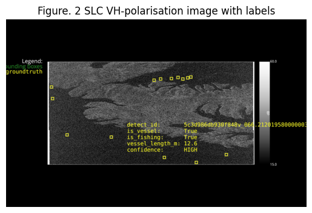

```python
# Plot the image inline using matplotlib
import matplotlib.pyplot as plt

img = plot_SLC.render()  # Capture the VisPy canvas as an image
plt.title("Figure. 2 SLC VH-polarisation image with labels")
plt.imshow(img)
plt.axis('off')
plt.show()
```

Figure 2 above, is the scaled, clipped and downsampled version of the SLC VH-polarisation product for scene_id '5c3d986db930f848v' (swath 2). The complex amplitude and phase data have been mapped into real intensity values for the display. Yellow boxes represent the bounding-boxes of the groundtruth labels, representing fishing vessels or non-fishing-vessels and where confidence = 'HIGH'.

```python
plot_SLC = None # free memory
```

## 5. Pre-processing

### 5.1 Scaling and normalisation

This section applies amplitude scaling and normalisation and phase normalisation to each image as per the recommendations in Section 4.1. Post-processing, the amplitude, phase and a 'zeros' channels are stacked into (height, width, channels) format.

*Under construction. One image array is processed below as an example.*

```python
# Extract amplitude and phase then scale and normalise amplitude and normalise phase.  (Same image array as used for Figure 1). Output in the format: (H, W, 3).
image_norm = process_complex_data(slc_data, epsilon=1e-6, nan_strategy='skip', verbose=True)
```

```python
print(f"image_norm size:{image_norm.size}, image_norm.shape: {image_norm.shape}, image_norm dtype:{image_norm.dtype}")
```

[output not shown]

### 5.2 Cropping images

### 5.3 Data augmentation

## 6. Modelling

#### Load the model

```python
from ultralytics import YOLO
import torch
```

```python
# Load the model
model = YOLO('yolo11n.pt')
```

#### Verify installation

```python
# Run inference on an image
results = model('https://ultralytics.com/images/bus.jpg')
```

```python
# Print detailed results with bounding boxes and confidence
for r in results:
    print(f"Detected {len(r.boxes)} objects")

    # Access bounding box information
    if r.boxes is not None:
        boxes = r.boxes.xyxy  # bounding boxes in xyxy format
        confidences = r.boxes.conf  # confidence scores
        classes = r.boxes.cls  # class indices

        print("\nDetailed detections:")
        for i, (box, conf, cls_idx) in enumerate(zip(boxes, confidences, classes)):
            x1, y1, x2, y2 = box.tolist()
            class_name = r.names[int(cls_idx)]

            print(f"Object {i+1}:")
            print(f"  Class: {class_name} (ID: {int(cls_idx)})")
            print(f"  Confidence: {conf:.4f}")
            print(f"  Bounding box: ({x1:.1f}, {y1:.1f}, {x2:.1f}, {y2:.1f})")
            print(f"  Box format: (x1, y1, x2, y2)")
            print()
```

[output not shown]

```python
# Save results with bounding boxes drawn
results[0].save('output_with_boxes.jpg')
```

```python
# Access the underlying PyTorch model
pytorch_model = model.model
```

#### Examine the architecture

```python
# View the model architecture
print(pytorch_model)
```

[output not shown]